# Do bigger Star Wars characters weigh more?

Author

Tamás Nagy

Published

September 22, 2026

```r
library(dplyr)
library(ggplot2)

theme_set(theme_light())
```

## The question

Body mass generally scales with height, and there is no obvious reason why the inhabitants of a fictional galaxy should be an exception. The `starwars` data that ships with dplyr gives us height and mass for most of the characters, so we can check.

This is a small enough dataset that we can look at every case, which turns out to matter.

## The data

```r
glimpse(starwars)
```

```
Rows: 87
Columns: 14
$ name       <chr> "Luke Skywalker", "C-3PO", "R2-D2", "Darth Vader", "Leia Or…
$ height     <int> 172, 167, 96, 202, 150, 178, 165, 97, 183, 182, 188, 180, 2…
$ mass       <dbl> 77.0, 75.0, 32.0, 136.0, 49.0, 120.0, 75.0, 32.0, 84.0, 77.…
$ hair_color <chr> "blond", NA, NA, "none", "brown", "brown, grey", "brown", N…
$ skin_color <chr> "fair", "gold", "white, blue", "white", "light", "light", "…
$ eye_color  <chr> "blue", "yellow", "red", "yellow", "brown", "blue", "blue",…
$ birth_year <dbl> 19.0, 112.0, 33.0, 41.9, 19.0, 52.0, 47.0, NA, 24.0, 57.0, …
$ sex        <chr> "male", "none", "none", "male", "female", "male", "female",…
$ gender     <chr> "masculine", "masculine", "masculine", "masculine", "femini…
$ homeworld  <chr> "Tatooine", "Tatooine", "Naboo", "Tatooine", "Alderaan", "T…
$ species    <chr> "Human", "Droid", "Droid", "Human", "Human", "Human", "Huma…
$ films      <list> <"A New Hope", "The Empire Strikes Back", "Return of the J…
$ vehicles   <list> <"Snowspeeder", "Imperial Speeder Bike">, <>, <>, <>, "Imp…
$ starships  <list> <"X-wing", "Imperial shuttle">, <>, <>, "TIE Advanced x1",…
```

The data covers 87 characters. Height and mass are recorded in centimetres and kilograms, and 28 characters are missing a mass — a little under a third, so the missingness is worth keeping in mind rather than ignoring.

## Descriptives

```r
starwars |>
  group_by(sex) |>
  summarise(
    n           = n(),
    mean_height = mean(height, na.rm = TRUE),
    mean_mass   = mean(mass,   na.rm = TRUE),
    .groups     = "drop"
  ) |>
  mutate(across(where(is.numeric), \(x) round(x, 1)))
```

```
# A tibble: 5 × 4
  sex                n mean_height mean_mass
  <chr>          <dbl>       <dbl>     <dbl>
1 female            16        172.      54.7
2 hermaphroditic     1        175     1358
3 male              60        179.      80.2
4 none               6        131.      69.8
5 <NA>               4        175       81
```

Without `na.rm = TRUE` every mean would come back as `NA`, which is R telling us something true but unhelpful: it cannot average numbers it does not have.

The `hermaphroditic` row is a single character, and its mean mass is a long way from everyone else’s. That is worth remembering when we get to the plot.

## Height against mass

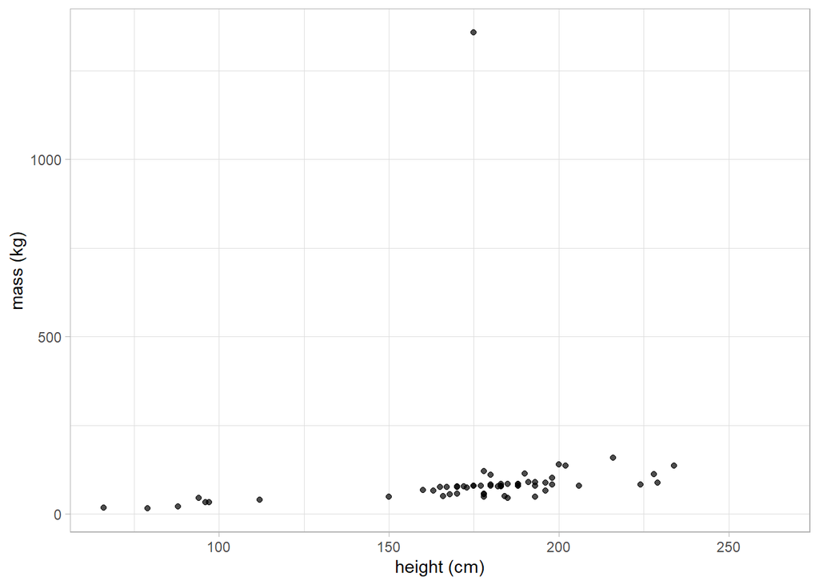

Figure 1: Height and mass for every character with both recorded.

```r
starwars |>
  ggplot(aes(height, mass)) +
  geom_point(alpha = 0.7) +
  labs(x = "height (cm)", y = "mass (kg)")
```

The plot is almost unreadable, and it is one point’s fault. A single character sits at over 1300 kg while everyone else is below 200, so the y axis stretches to accommodate it and the remaining 58 characters are squashed into a band along the bottom.

Whatever the relationship between height and mass is, this figure cannot show it.

## The outlier

```r
starwars |>
  select(name, height, mass, species) |>
  arrange(desc(mass)) |>
  head(3)
```

```
# A tibble: 3 × 4
  name                  height  mass species
  <chr>                  <int> <dbl> <chr>
1 Jabba Desilijic Tiure    175  1358 Hutt
2 Grievous                 216   159 Kaleesh
3 IG-88                    200   140 Droid
```

It is Jabba, who is a large slug, and whose mass is about eight and a half times that of the next heaviest character. He is not a data entry error — he really is that heavy — but he is not the same kind of thing as the others.

```r
r_all <- cor(starwars$height, starwars$mass, use = "complete.obs")

no_jabba <- starwars |> filter(!grepl("Jabba", name))

r_nojabba <- cor(no_jabba$height, no_jabba$mass, use = "complete.obs")

c(all = r_all, without_jabba = r_nojabba) |> round(3)
```

```
          all without_jabba
        0.131         0.751
```

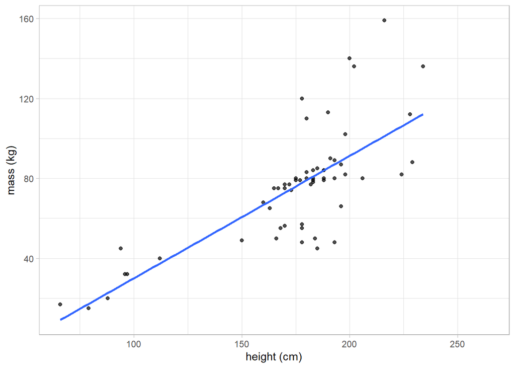

Figure 2: The same plot with Jabba removed.

```r
no_jabba |>
  ggplot(aes(height, mass)) +
  geom_point(alpha = 0.7) +
  geom_smooth(method = "lm", formula = y ~ x, se = FALSE) +
  labs(x = "height (cm)", y = "mass (kg)")
```

## Conclusion

With every character included, the correlation between height and mass is 0.13 — near enough to nothing. With Jabba excluded it is 0.75, a strong positive relationship of roughly the size you would expect.

One observation out of 59 moves the answer from “no relationship” to “a strong one”. I would report the second figure, because the question is about how height and mass scale among broadly humanoid characters and Jabba is not one. But that is a judgment, not a calculation, and the honest way to present it is to report both numbers and say which I chose — which is what this paragraph does.

Note that every number in it was computed rather than typed. If a character were added to the data tomorrow, re-rendering this file would correct the prose.

## Notes for the instructor

- The `na.rm` stumble in the summary table is deliberate and worth letting people hit.
- Task 6 asks for interpretation before the outlier is named. Some will spot Jabba immediately; others will only say “one point is weird”. Both are fine.
- The 0.13 to 0.75 jump is the moment to connect forward to part 3: here the decision is easy because you can see everything. In the blinding exercise you will have to make the same kind of call without knowing which way it cuts.